# 5.2 Bootstrap

hyojunahn

# Bootstrap

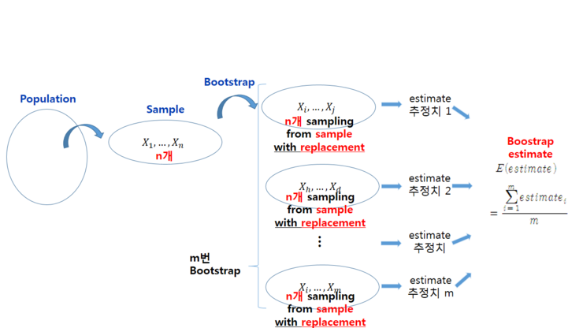

## 부트스트랩(Bootstrap)

### 모집단에 대한 어떤 가정도 없이 표본에서 표본 데이터를 반복적으로 추출한다. 복원 추출법을 사용하여 새로운 여러 표본을 만들어낸다. 새로운 표본은 원래 데이터 겟에 있는 값으로만 구성.

### 동일한 값이 여러개 포함될 수 있다. 이 방법을 통해 일반적인 분포 뿐만 아니라 새로운 통계 분포도 살펴볼 수 있다. 모집단에 대한 어떤 것도 가정하지 않기 때문에 통계 분석과 신뢰 구간을 구할 수 있다.

### 동일한 데이터를 사용해 평균을 계산하고 주어진 데이터에 대한 분산을 구한다. 평균의 표준오차나 평균 차이의 표준 오차를 구할 수 있다.

> 평균의 신뢰구간을 알고 싶거나 수집한 데이터의 확률 변수의 정확한 분포를 모르는 경우에는 붓스트랩을 사용한다. 측정된 nt 개의 데이터 중에서 중복을 허용하여 m개를 뽑고 그들의 평균 구하기를 여러번 반복한다. sample mean을 통해 신뢰 구간을 구할 수 있다.

# 방법

1. 모집단으로 부터 sample n개를 뽑는다. (데이터 개수가 n개)
2. Bootstrap을 m번 했다. (보통 1,000번 정도) -. n개의 sample에서 복원추출 n개를, m번 한다. 즉, Bootstrap을 한번 할 때, sample의 개수는 n개이다. -. 복원추출된 m개의 그룹 각각에서, 추정하고자 하는 것을 추정한다.
3. 복원추출된 m개의 그룹 각각에서, 추정한 추정치들의 평균값을 구한다.
4. 이 평균값이 Boostrap 추정값이다.

## 책

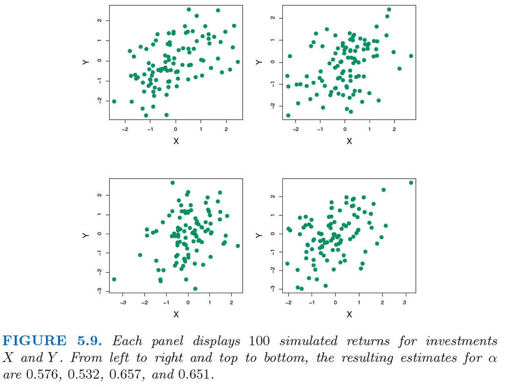

### Rather than repeatedly obtaining independent data sets from the population, we instead obtain distinct data sets by repeatedly sampling observations from the original data set.

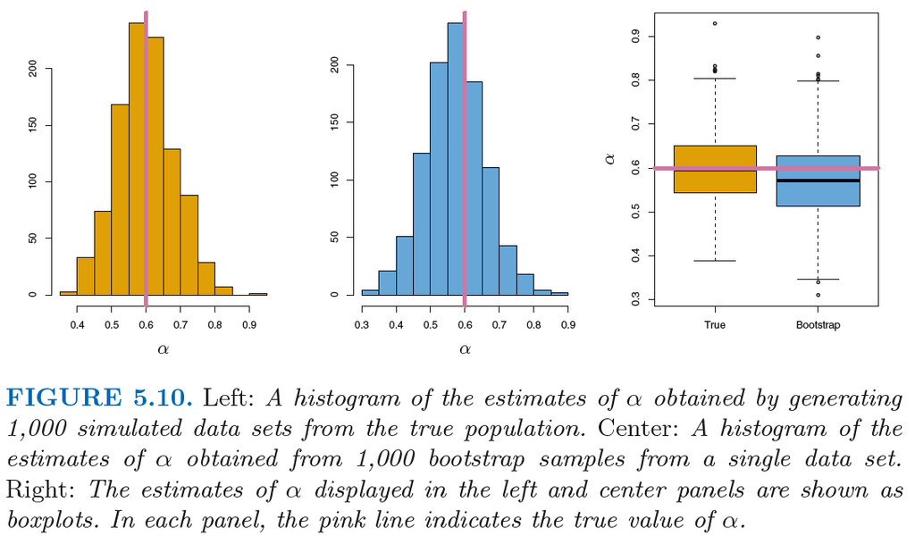

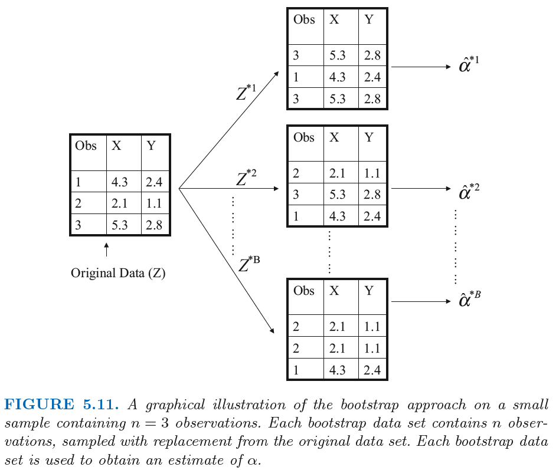